# WBE for SARS-CoV-2 in Switzerland: model development (A)

Julien Riou

2023-04-24

2023-05-09

```r
source("setup.R")
ww1 = readRDS(fs::path("../",controls$savepoint,"ww1.rds"))
# plot function
ppp_day = function(dat,mod) {
  mod$summary.fitted.values %>%
    dplyr::bind_cols(dat) %>%
    ggplot(aes(x=date)) +
    geom_point(aes(y=logvl)) +
    geom_ribbon(aes(ymin=`0.025quant`,ymax=`0.975quant`),alpha=.5,fill=cust_cols[1]) +
    geom_line(aes(y=mean),colour=cust_cols[1]) +
    annotate(x=min(dat$date),y=min(dat$logvl),geom="text",label=paste0("WAIC=",round(mod$waic$waic)),hjust=0)
}
# k-fold cross validation
kfoldcv = function(dat,mod,k=10) {
  # extract formula
  ff = as.character(mod$.args$formula)
  ff = as.formula(paste(ff[2],ff[1],ff[3]))
  # adapt data
  dd = dat %>%
    dplyr::mutate(k=sample(1:k,nrow(dat),replace=TRUE),
                  mean=NA,lbd=NA,upb=NA)
  # run k-fold cv
  for(i in 1:10) {
    rr = which(dd$k==i)
    ddx = dd %>%
      dplyr::mutate(logvl = ifelse(k==i,NA,logvl))
    mm = INLA::inla(ff,
               data = ddx,
               family = "gamma",
               control.mode = list(result = mod, restart=TRUE),
               control.predictor = list(compute=TRUE,link=1))
    dd[rr,"mean"] = mm$summary.fitted.values[rr,"mean"]
    dd[rr,"lbd"] = mm$summary.fitted.values[rr,"0.025quant"]
    dd[rr,"upb"] = mm$summary.fitted.values[rr,"0.975quant"]
  }
  oo = dd %>%
    dplyr::mutate(se=(logvl-mean)^2,
                  coverage=ifelse(logvl>lbd & logvl<upb,1,0)) %>%
    summarise(rmse=sqrt(mean(se)),
              coverage=mean(coverage)) %>%
    unlist() %>% unname()
  output = list(RMSE=round(oo[1],2),
                coverage=round(oo[2],2))
  return(output)
}
```

```r
source("setup.R")
ww1 = readRDS(fs::path("../",controls$savepoint,"ww1.rds"))
compute_cv = TRUE
# plot function
ppp_day = function(dat,mod) {
  mod$summary.fitted.values %>%
    dplyr::bind_cols(dat) %>%
    ggplot(aes(x=date)) +
    geom_point(aes(y=logvl)) +
    geom_ribbon(aes(ymin=`0.025quant`,ymax=`0.975quant`),alpha=.5,fill=cust_cols[1]) +
    geom_line(aes(y=mean),colour=cust_cols[1]) +
    annotate(x=min(dat$date),y=min(dat$logvl),geom="text",label=paste0("WAIC=",round(mod$waic$waic)),hjust=0)
}
# k-fold cross validation
kfoldcv = function(dat,mod,k=10) {
  # extract formula
  ff = as.character(mod$.args$formula)
  ff = as.formula(paste(ff[2],ff[1],ff[3]))
  # adapt data
  ser = rep(1:k,length.out=nrow(dat))
  ser = ser[order(ser)]
  dd = dat %>%
    # dplyr::mutate(k=sample(1:k,nrow(dat),replace=TRUE),
    dplyr::mutate(k=ser,
                  mean=NA,lbd=NA,upb=NA)
  # run k-fold cv
  for(i in 1:k) {
    rr = which(dd$k==i)
    ddx = dd %>%
      dplyr::mutate(logvl = ifelse(k==i,NA,logvl))
    mm = INLA::inla(ff,
                    data = ddx,
                    family = "gamma",
                    control.mode = list(result = mod, restart=TRUE),
                    control.predictor = list(compute=TRUE,link=1))
    dd[rr,"mean"] = mm$summary.fitted.values[rr,"mean"]
    dd[rr,"lbd"] = mm$summary.fitted.values[rr,"0.025quant"]
    dd[rr,"upb"] = mm$summary.fitted.values[rr,"0.975quant"]
  }
  oo = dd %>%
    dplyr::filter(!is.na(logvl)) %>%
    dplyr::mutate(se=(logvl-mean)^2,
                  coverage=ifelse(logvl>lbd & logvl<upb,1,0)) %>%
    summarise(rmse=sqrt(mean(se)),
              coverage=mean(coverage)) %>%
    unlist() %>% unname()
  output = list(RMSE=round(oo[1],2),
                coverage=round(oo[2],2))
  return(output)
}
```

# 1 One ARA

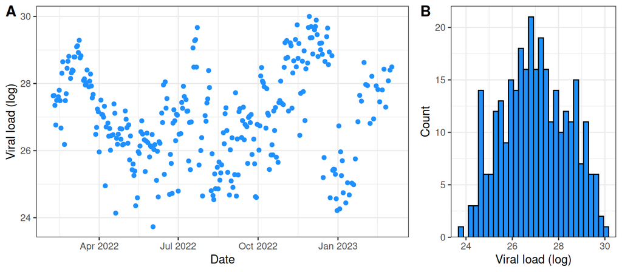

```r
# select one ARA
chosen_ara = "Aarau"
# data management
ww_one = ww1 %>%
  filter(ara_name==chosen_ara) %>%
  # remove missing
  filter(!is.na(vl)) %>%
  # log
  mutate(logvl=log(vl)) %>%
  # manage dates
  mutate(day=as.numeric(date)-min(as.numeric(date)),
         weekend=if_else(lubridate::wday(date,week_start=1)>=5,1,0)) %>%
  rownames_to_column()
# plot
g1 = ggplot(ww_one) +
  geom_point(aes(x=date,y=logvl),colour=cust_cols[1]) +
  labs(x="Date",y="Viral load (log)")
g2 = ggplot(ww_one) +
  geom_histogram(aes(x=logvl),fill=cust_cols[1],colour="black",bins=30) +
  scale_y_continuous(expand=expansion(c(0,0.05))) +
  labs(x="Viral load (log)",y="Count")
cowplot::plot_grid(g1,g2,labels=c("A","B"),rel_widths = c(2,1))
```

**Figure 1.** SARS-CoV-2 viral load in wastewater in Aarau (panel A: measurements over time; panel B: histogram).

## Model A1: gamma regression

We select gamma regression with a log link as the dependent variable is continuous and strictly positive. The log link also implies that all effects will be multiplicative. This is espacially useful as ultimately changes in the log viral load over time are expected to follow the epidemic dynamic of SARS-CoV-2, so with exponential growth and exponential decay.

The first, basic model only includes a linear trend over time.

$$\log(logV) = \alpha + \beta t$$

```r
ma1 = INLA::inla(logvl ~ 1 + day,
                 data = ww_one,
                 family = "gamma",
                 control.compute = list(waic=TRUE,config=TRUE))
summary(ma1)
```

```
##
## Call:
##    c("inla.core(formula = formula, family = family, contrasts = contrasts, ", " data = data,
##    quantiles = quantiles, E = E, offset = offset, ", " scale = scale, weights = weights,
##    Ntrials = Ntrials, strata = strata, ", " lp.scale = lp.scale, link.covariates =
##    link.covariates, verbose = verbose, ", " lincomb = lincomb, selection = selection,
##    control.compute = control.compute, ", " control.predictor = control.predictor,
##    control.family = control.family, ", " control.inla = control.inla, control.fixed =
##    control.fixed, ", " control.mode = control.mode, control.expert = control.expert, ", "
##    control.hazard = control.hazard, control.lincomb = control.lincomb, ", " control.update =
##    control.update, control.lp.scale = control.lp.scale, ", " control.pardiso =
##    control.pardiso, only.hyperparam = only.hyperparam, ", " inla.call = inla.call, inla.arg
##    = inla.arg, num.threads = num.threads, ", " blas.num.threads = blas.num.threads, keep =
##    keep, working.directory = working.directory, ", " silent = silent, inla.mode = inla.mode,
##    safe = FALSE, debug = debug, ", " .parent.frame = .parent.frame)")
## Time used:
##     Pre = 0.559, Running = 0.116, Post = 0.0357, Total = 0.711
## Fixed effects:
##             mean    sd 0.025quant 0.5quant 0.975quant mode kld
## (Intercept) 3.29 0.006      3.279     3.29      3.302 3.29   0
## day         0.00 0.000      0.000     0.00      0.000 0.00   0
##
## Model hyperparameters:
##                                                  mean    sd 0.025quant 0.5quant 0.975quant   mode
## Precision parameter for the Gamma observations 365.51 29.44     310.12   364.72     425.45 363.14
##
## Watanabe-Akaike information criterion (WAIC) ...: 1084.62
## Effective number of parameters .................: 2.58
##
## Marginal log-Likelihood:  -562.33
##  is computed
## Posterior summaries for the linear predictor and the fitted values are computed
## (Posterior marginals needs also 'control.compute=list(return.marginals.predictor=TRUE)')
```

```r
kfoldcv(ww_one,ma1)
```

```
## $RMSE
## [1] 1.41
##
## $coverage
## [1] 0.12
```

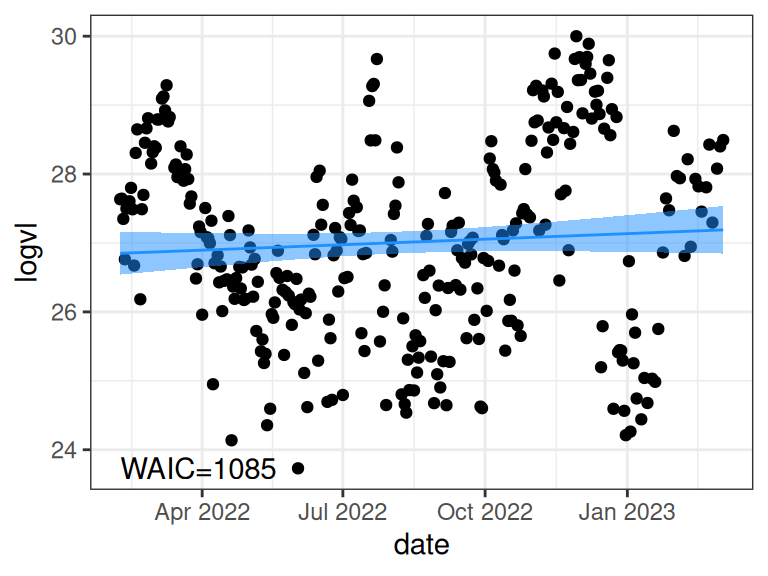

```r
ppp_day(ww_one,ma1)
```

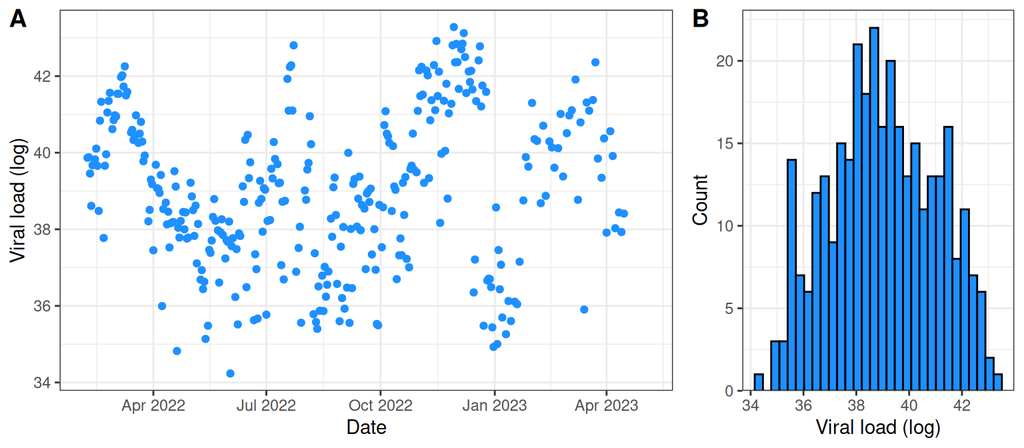

```r
# select one ARA
chosen_ara = "Aarau"
# data management
ww_one = ww1 %>%
  filter(ara_name==chosen_ara) %>%
  # log
  mutate(logvl=log2(vl)) %>%
  # manage dates
  mutate(day=as.numeric(date)-min(as.numeric(date)),
         weekend=if_else(lubridate::wday(date,week_start=1)>=5,1,0)) %>%
  rownames_to_column()
# plot
g1 = ggplot(ww_one) +
  geom_point(aes(x=date,y=logvl),colour=cust_cols[1]) +
  labs(x="Date",y="Viral load (log)")
g2 = ggplot(ww_one) +
  geom_histogram(aes(x=logvl),fill=cust_cols[1],colour="black",bins=30) +
  scale_y_continuous(expand=expansion(c(0,0.05))) +
  labs(x="Viral load (log)",y="Count")
cowplot::plot_grid(g1,g2,labels=c("A","B"),rel_widths = c(2,1))
```

**Figure 1.** SARS-CoV-2 viral load in wastewater in Aarau (panel A: measurements over time; panel B: histogram).

## 1.1 Model A1: gamma regression

We select gamma regression with a log link as the dependent variable is continuous and strictly positive. The log link implies an exponential trend over time. This is especially useful as ultimately changes in the log viral load over time are expected to follow the epidemic dynamic of SARS-CoV-2, so with exponential growth and exponential decay.

The first, basic model only includes a exponential trend over time.

$$\log(log2V) = \alpha + \beta t$$

```r
ma1 = INLA::inla(logvl ~ 1 + day,
                 data = ww_one,
                 family = "gamma",
                 control.compute = list(waic=TRUE,config=TRUE),
                 control.predictor = list(compute=TRUE,link=1))
summary(ma1)
```

```
##
## Call:
##    c("inla.core(formula = formula, family = family, contrasts = contrasts, ", " data = data,
##    quantiles = quantiles, E = E, offset = offset, ", " scale = scale, weights = weights, Ntrials
##    = Ntrials, strata = strata, ", " lp.scale = lp.scale, link.covariates = link.covariates,
##    verbose = verbose, ", " lincomb = lincomb, selection = selection, control.compute =
##    control.compute, ", " control.predictor = control.predictor, control.family = control.family,
##    ", " control.inla = control.inla, control.fixed = control.fixed, ", " control.mode =
##    control.mode, control.expert = control.expert, ", " control.hazard = control.hazard,
##    control.lincomb = control.lincomb, ", " control.update = control.update, control.lp.scale =
##    control.lp.scale, ", " control.pardiso = control.pardiso, only.hyperparam = only.hyperparam,
##    ", " inla.call = inla.call, inla.arg = inla.arg, num.threads = num.threads, ", "
##    blas.num.threads = blas.num.threads, keep = keep, working.directory = working.directory, ", "
##    silent = silent, inla.mode = inla.mode, safe = FALSE, debug = debug, ", " .parent.frame =
##    .parent.frame)")
## Time used:
##     Pre = 0.693, Running = 0.124, Post = 0.0353, Total = 0.852
## Fixed effects:
##              mean    sd 0.025quant 0.5quant 0.975quant  mode kld
## (Intercept) 3.656 0.006      3.645    3.656      3.667 3.656   0
## day         0.000 0.000      0.000    0.000      0.000 0.000   0
##
## Model hyperparameters:
##                                                  mean    sd 0.025quant 0.5quant 0.975quant   mode
## Precision parameter for the Gamma observations 371.98 29.12     317.12   371.23     431.22 369.70
##
## Watanabe-Akaike information criterion (WAIC) ...: 1381.81
## Effective number of parameters .................: 2.49
##
## Marginal log-Likelihood:  -711.19
##  is computed
## Posterior summaries for the linear predictor and the fitted values are computed
## (Posterior marginals needs also 'control.compute=list(return.marginals.predictor=TRUE)')
```

```r
if(compute_cv) kfoldcv(ww_one,ma1)
```

```
## $RMSE
## [1] 2.28
##
## $coverage
## [1] 0.13
```

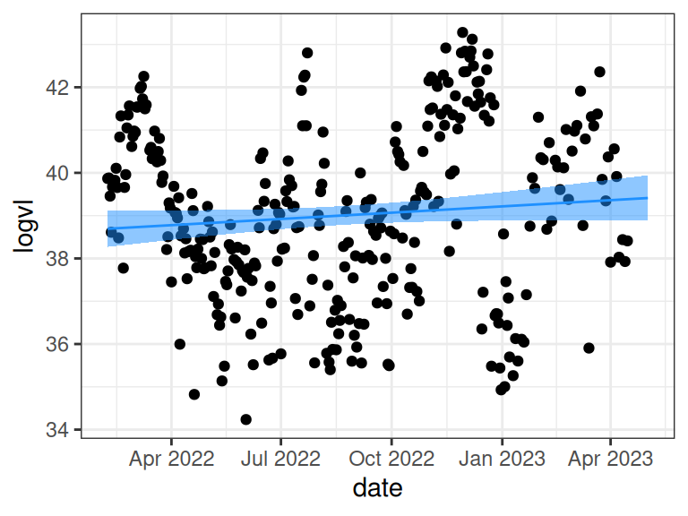

```r
ppp_day(ww_one,ma1)
```

In the output we can see the call, the used time in seconds, the posterior estimates of the parameters and hyperparameters, and the WAIC. We also look at the posterior predictive plot comparing the data with model predictions. Obviously it will not produce a good fit of the data, it’s just meant as a starting point.

## Model A2: random walk

We deal with the variation in log viral load over time with a random walk, so that the difference between two successive observations follows a normal distribution.

```r
ma2 = INLA::inla(logvl ~ 1 +
                   f(day, model="rw1", scale.model=TRUE, constr=TRUE),
                 data = ww_one,
                 family = "gamma",
                 control.compute = list(waic=TRUE))
summary(ma2)
```

[output not shown]

[output cut: 271 more lines]

[output not shown]

[figure not shown]

[figure not shown]

[figure not shown]

[figure not shown]

[figure not shown]

```r
if(compute_cv) kfoldcv(ww_one,ma4)
```

```
## $RMSE
## [1] 1.93
##
## $coverage
## [1] 0.68
```

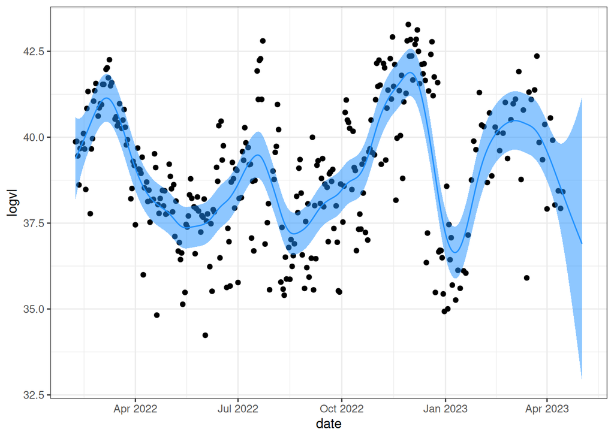

```r
ppp_day(ww_one,ma4)
```

The model now appropriately captures the dynamics of SARS-CoV-2 viral load, although still underestimates the variability especially during certain periods.

## 1.5 Model A5: additional covariates

There are other covariates available at the level of an ARA that may explain part of the residual variability. One is a change in the methods used to quantify SARS-CoV-2. A second is the day of the week, as behaviour may change for instance during weekends.

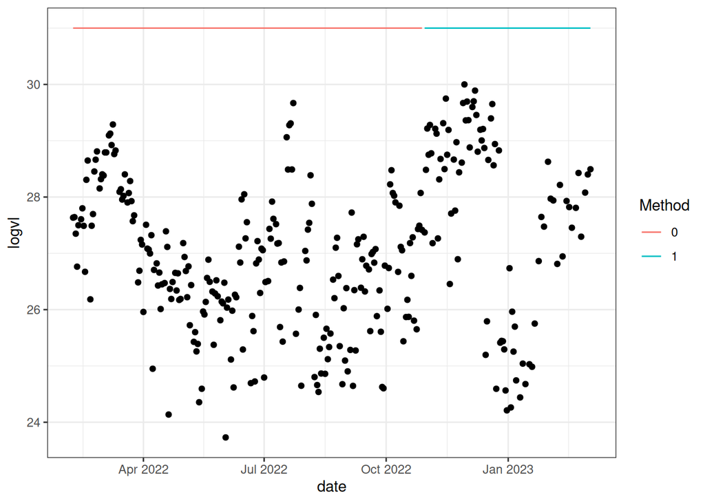

```r
ggplot(ww_one) +
  geom_point(aes(x=date,y=logvl)) +
  geom_line(aes(x=date,y=31,colour=factor(method))) +
  labs(colour="Method")
```

```r
ma5 = INLA::inla(logvl ~ 1 +
                   f(day,model="rw2", scale.model=TRUE, constr=TRUE,
                     hyper=list(prec = list(prior = "pc.prec", param = c(1, 0.01)))) +
                   method +
                   weekend,
                 data = ww_one,
                 family = "gamma",
                 control.compute = list(waic=TRUE))
summary(ma5)
```

[output not shown]

[output cut: 34 more lines]

[output not shown]

[figure not shown]

[figure not shown]

## Model A6: AR

A similar idea is to use an auto-regressive model of order 1, where the value of observation $i$ depends on the value of observation $i-1$ scaled by a parameter $\rho$.

```r
ma6 = INLA::inla(logvl ~ 1 +
                   f(day,model="ar1", constr=TRUE),
                 data = ww_one,
                 family = "gamma",
                 control.compute = list(waic=TRUE))
summary(ma6)
```

```
##
## Call:
##    c("inla.core(formula = formula, family = family, contrasts = contrasts, ", " data = data,
##    quantiles = quantiles, E = E, offset = offset, ", " scale = scale, weights = weights,
##    Ntrials = Ntrials, strata = strata, ", " lp.scale = lp.scale, link.covariates =
##    link.covariates, verbose = verbose, ", " lincomb = lincomb, selection = selection,
##    control.compute = control.compute, ", " control.predictor = control.predictor,
##    control.family = control.family, ", " control.inla = control.inla, control.fixed =
##    control.fixed, ", " control.mode = control.mode, control.expert = control.expert, ", "
##    control.hazard = control.hazard, control.lincomb = control.lincomb, ", " control.update =
##    control.update, control.lp.scale = control.lp.scale, ", " control.pardiso =
##    control.pardiso, only.hyperparam = only.hyperparam, ", " inla.call = inla.call, inla.arg
##    = inla.arg, num.threads = num.threads, ", " blas.num.threads = blas.num.threads, keep =
##    keep, working.directory = working.directory, ", " silent = silent, inla.mode = inla.mode,
##    safe = FALSE, debug = debug, ", " .parent.frame = .parent.frame)")
## Time used:
##     Pre = 0.398, Running = 0.177, Post = 0.0364, Total = 0.612
## Fixed effects:
##              mean    sd 0.025quant 0.5quant 0.975quant  mode kld
## (Intercept) 3.295 0.002      3.292    3.295      3.298 3.295   0
##
## Random effects:
##   Name     Model
##     day AR1 model
##
## Model hyperparameters:
##                                                    mean      sd 0.025quant 0.5quant 0.975quant
## Precision parameter for the Gamma observations 1212.543 143.562    950.590 1205.628   1515.445
## Precision for day                               568.707 141.673    327.968  556.531    881.883
## Rho for day                                       0.915   0.025      0.859    0.917      0.958
##                                                    mode
## Precision parameter for the Gamma observations 1194.084
## Precision for day                               535.772
## Rho for day                                       0.922
##
## Watanabe-Akaike information criterion (WAIC) ...: 783.25
## Effective number of parameters .................: 72.87
##
## Marginal log-Likelihood:  -453.73
##  is computed
## Posterior summaries for the linear predictor and the fitted values are computed
## (Posterior marginals needs also 'control.compute=list(return.marginals.predictor=TRUE)')
```

```r
kfoldcv(ww_one,ma6)
```

```
## $RMSE
## [1] 0.88
##
## $coverage
## [1] 0.8
```

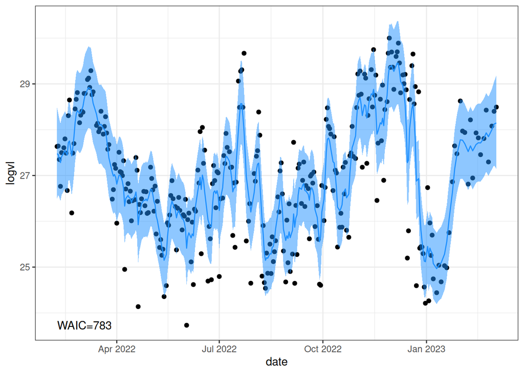

```r
ppp_day(ww_one,ma6)
```

Results appear similar to model A2.

## Model A7: splines

An alternative could be using splines. The downside is that we have to choose knots. We can start with a knot every 30 days.

```r
cknots = seq(from=0,to=max(ww_one$day),by=30)
ma7 = INLA::inla(logvl ~ 1 +
                   bs(day,knots = cknots),
                 data = ww_one,
                 family = "gamma",
                 control.compute = list(waic=TRUE))
summary(ma7)
```

```
##
## Call:
##    c("inla.core(formula = formula, family = family, contrasts = contrasts, ", " data = data,
##    quantiles = quantiles, E = E, offset = offset, ", " scale = scale, weights = weights,
##    Ntrials = Ntrials, strata = strata, ", " lp.scale = lp.scale, link.covariates =
##    link.covariates, verbose = verbose, ", " lincomb = lincomb, selection = selection,
##    control.compute = control.compute, ", " control.predictor = control.predictor,
##    control.family = control.family, ", " control.inla = control.inla, control.fixed =
##    control.fixed, ", " control.mode = control.mode, control.expert = control.expert, ", "
##    control.hazard = control.hazard, control.lincomb = control.lincomb, ", " control.update =
##    control.update, control.lp.scale = control.lp.scale, ", " control.pardiso =
##    control.pardiso, only.hyperparam = only.hyperparam, ", " inla.call = inla.call, inla.arg
##    = inla.arg, num.threads = num.threads, ", " blas.num.threads = blas.num.threads, keep =
##    keep, working.directory = working.directory, ", " silent = silent, inla.mode = inla.mode,
##    safe = FALSE, debug = debug, ", " .parent.frame = .parent.frame)")
## Time used:
##     Pre = 0.579, Running = 0.126, Post = 0.0456, Total = 0.75
## Fixed effects:
##               mean     sd 0.025quant 0.5quant 0.975quant   mode kld
## (Intercept)  3.302  7.906    -12.202    3.302     18.806  3.302   0
## 1            0.006  7.906    -15.499    0.006     15.510  0.006   0
## 2            0.009  7.906    -15.495    0.009     15.514  0.009   0
## 3            0.100  7.906    -15.404    0.100     15.605  0.100   0
## 4           -0.052  7.906    -15.556   -0.052     15.452 -0.052   0
## 5           -0.024  7.906    -15.528   -0.024     15.481 -0.024   0
## 6           -0.076  7.906    -15.581   -0.076     15.428 -0.076   0
## 7            0.035  7.906    -15.470    0.035     15.539  0.035   0
## 8           -0.042  7.906    -15.546   -0.042     15.463 -0.042   0
## 9           -0.058  7.906    -15.562   -0.058     15.447 -0.058   0
## 10           0.000  7.906    -15.504    0.000     15.504  0.000   0
## 11          -0.008  7.906    -15.512   -0.008     15.496 -0.008   0
## 12           0.156  7.906    -15.348    0.156     15.660  0.156   0
## 13          -0.152  7.906    -15.656   -0.152     15.352 -0.152   0
## 14           0.045  7.906    -15.459    0.045     15.549  0.045   0
## 15           0.018  7.906    -15.487    0.018     15.522  0.018   0
## 16           0.042  7.906    -15.462    0.042     15.547  0.042   0
## 17           0.000 31.623    -62.017    0.000     62.017  0.000   0
##
## Model hyperparameters:
##                                                  mean    sd 0.025quant 0.5quant 0.975quant   mode
## Precision parameter for the Gamma observations 722.35 59.56     610.40   720.73     843.74 717.44
##
## Watanabe-Akaike information criterion (WAIC) ...: 879.25
## Effective number of parameters .................: 13.62
##
## Marginal log-Likelihood:  -549.52
##  is computed
## Posterior summaries for the linear predictor and the fitted values are computed
## (Posterior marginals needs also 'control.compute=list(return.marginals.predictor=TRUE)')
```

```r
kfoldcv(ww_one,ma7)
```

```
## $RMSE
## [1] 0.99
##
## $coverage
## [1] 0.43
```

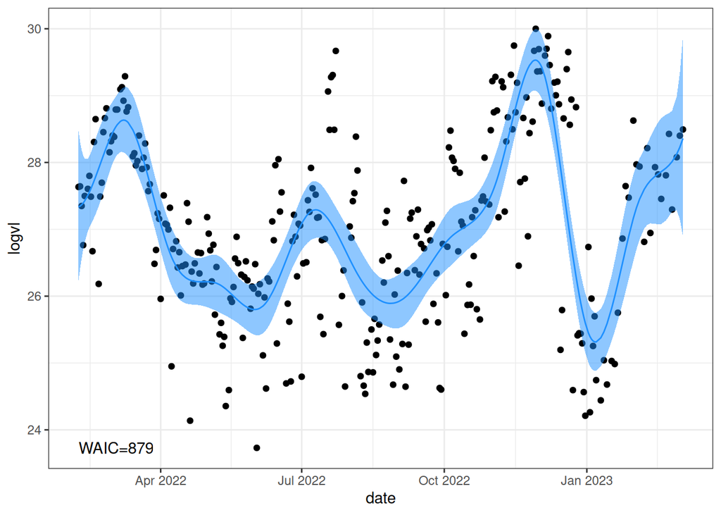

```r
ppp_day(ww_one,ma7)
```

```r
if(compute_cv) kfoldcv(ww_one,ma5)
```

```
## $RMSE
## [1] 2.03
##
## $coverage
## [1] 0.75
```

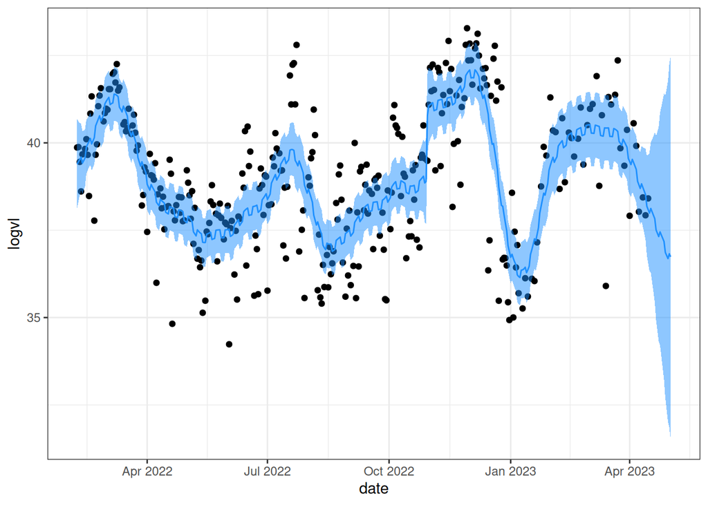

```r
ppp_day(ww_one,ma5)
```

While the effect size is small, we observe an improvement in the fit.

# 2 All ARAs

```r
ww_all = ww1 %>%
  # log
  mutate(logvl=log2(vl)) %>%
  # manage dates
  mutate(day=as.numeric(date)-min(as.numeric(date)),
         weekend=if_else(lubridate::wday(date,week_start=1)>=5,1,0)) %>%
  rownames_to_column()
```

## 2.1 Model A6: multiple ARAs

There are other covariates available at the level of an ARA that may explain part of the residual variability. One is a change in the methods used to quantify SARS-CoV-2. A second is the day of the week, as behaviour may change for instance during weekends.

```r
#
# ma6 = INLA::inla(logvl ~ 1 +
#                    f(day,model="rw2", scale.model=TRUE, constr=TRUE,
#                      hyper=list(prec = list(prior = "pc.prec", param = c(1, 0.01)))) +
#                    f(ara_n,model="iid") +
#                    method +
#                    weekend,
#                  data = ww_all,
#                  family = "normal",
#                  control.compute = list(waic=TRUE))
# summary(ma6)
# # kfoldcv(ww_one,ma5)
# mod = ma6
# dat = ww_all
# ppp_day = function(dat,mod) {
#   mod$summary.fitted.values %>%
#     dplyr::bind_cols(dat) %>%
#     ggplot(aes(x=date)) +
#     geom_point(aes(y=logvl)) +
#     geom_ribbon(aes(ymin=`0.025quant`,ymax=`0.975quant`),alpha=.5,fill=cust_cols[1]) +
#     geom_line(aes(y=mean),colour=cust_cols[1]) +
#     annotate(x=min(dat$date),y=min(dat$logvl),geom="text",label=paste0("WAIC=",round(mod$waic$waic)),hjust=0)
# }
```